# Homework 3: Solution

We start by considering the model postulated by Scientist A:

```r
library(idarps)
data("cortisol")

# Log transform
cortisol$log_cortisol = log(cortisol$cortisol)

# Model of Scientist A
mod_scientist_A = lm(log_cortisol ~ caloric, data = cortisol)
summary(mod_scientist_A)
```

```
##
## Call:
## lm(formula = log_cortisol ~ caloric, data = cortisol)
##
## Residuals:
##     Min      1Q  Median      3Q     Max
## -1.8395 -0.5889  0.1799  0.6998  1.8756
##
## Coefficients:
##               Estimate Std. Error t value Pr(>|t|)
## (Intercept)  8.7732375  0.5228605  16.779  < 2e-16 ***
## caloric     -0.0006702  0.0001683  -3.983  0.00019 ***
## ---
## Signif. codes:  0 '***' 0.001 '**' 0.01 '*' 0.05 '.' 0.1 ' ' 1
##
## Residual standard error: 0.8741 on 59 degrees of freedom
## Multiple R-squared:  0.2119, Adjusted R-squared:  0.1985
## F-statistic: 15.86 on 1 and 59 DF,  p-value: 0.0001895
```

Next, we evaluate graphically the adequacy of this model with the data:

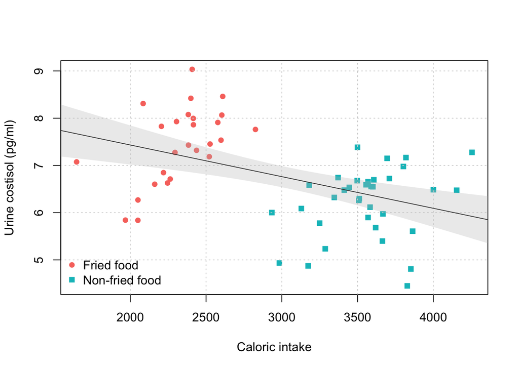

```r
colors = c("#F8766D", "#00BFC4")
plot(cortisol$caloric, cortisol$log_cortisol,
     xlab = "Caloric intake", ylab = "Urine costisol (pg/ml)",
     col = colors[as.numeric(cortisol$group == "NC") + 1],
     pch = 15 + as.numeric(cortisol$group == "C"))
grid()
legend("bottomleft", c("Fried food", "Non-fried food"), col = colors, pch = c(16, 15), bty = "n")

cal_to_predict = 1500:4500
pred = predict(mod_scientist_A, data.frame(caloric = cal_to_predict), interval = "confidence")
lines(cal_to_predict, pred[,1])
polygon(c(cal_to_predict, rev(cal_to_predict)), c(pred[,2], rev(pred[,3])), col = "#BEBEBE4C", border = NA)
```

It is quite clear that the model of Scientist A is not a suitable model to describe the data, as it doesn’t take into account the effects of groups. We can have a look at the diagnostic plots which convey the same message:

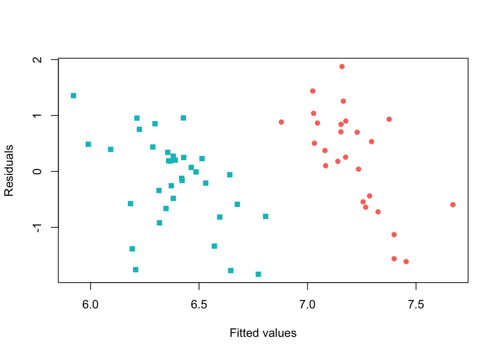

```r
plot(predict(mod_scientist_A), resid(mod_scientist_A),
     xlab = "Fitted values", ylab = "Residuals",
     col = colors[as.numeric(cortisol$group == "NC") + 1],
     pch = 15 + as.numeric(cortisol$group == "C"))
```

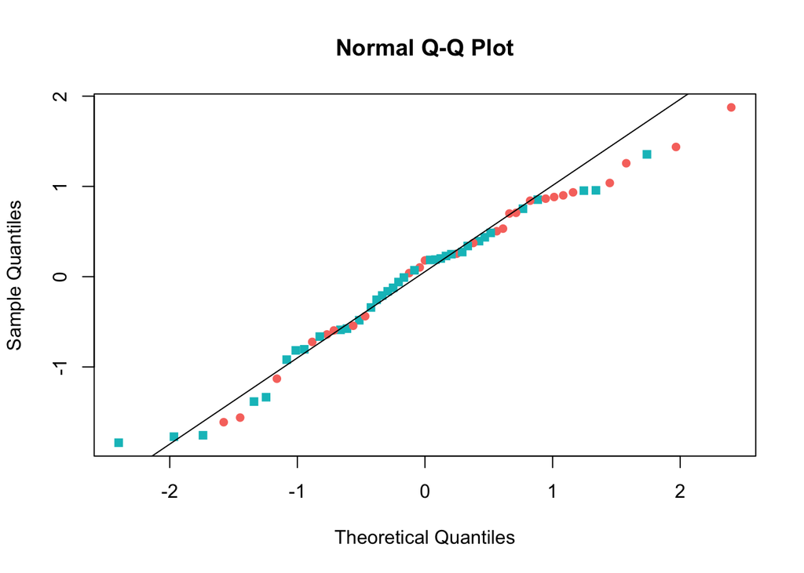

```r
qqnorm(resid(mod_scientist_A), col = colors[as.numeric(cortisol$group == "NC") + 1],
       pch = 15 + as.numeric(cortisol$group == "C"))
qqline(resid(mod_scientist_A))
```

As we can see, these graphs (mainly the first one actually) show that this model proposed by Scientist A doesn’t appear adequate to model the data we are considering.

Next, we consider the model of Scientist B:

```r
# Model of Scientist B
mod_scientist_B = lm(log_cortisol ~ caloric + group, data = cortisol)
summary(mod_scientist_B)
```

```
##
## Call:
## lm(formula = log_cortisol ~ caloric + group, data = cortisol)
##
## Residuals:
##     Min      1Q  Median      3Q     Max
## -2.0341 -0.4551  0.2124  0.4368  1.5076
##
## Coefficients:
##               Estimate Std. Error t value Pr(>|t|)
## (Intercept)  5.0968675  0.7986440   6.382 3.17e-08 ***
## caloric      0.0010089  0.0003373   2.991  0.00407 **
## groupNC     -2.4746749  0.4535788  -5.456 1.05e-06 ***
## ---
## Signif. codes:  0 '***' 0.001 '**' 0.01 '*' 0.05 '.' 0.1 ' ' 1
##
## Residual standard error: 0.7167 on 58 degrees of freedom
## Multiple R-squared:  0.4792, Adjusted R-squared:  0.4612
## F-statistic: 26.68 on 2 and 58 DF,  p-value: 6.082e-09
```

Similarly, we evaluate graphically the adequacy of this model with the data:

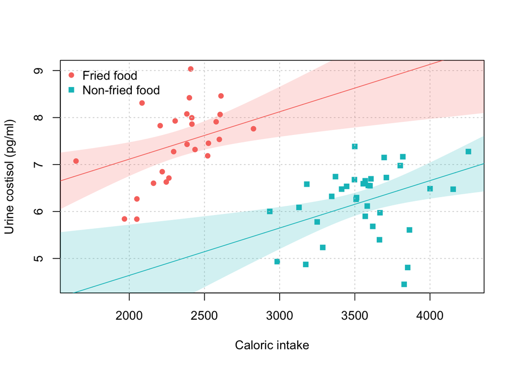

```r
colors = c("#F8766D", "#00BFC4")
plot(cortisol$caloric, cortisol$log_cortisol,
     xlab = "Caloric intake", ylab = "Urine costisol (pg/ml)",
     col = colors[as.numeric(cortisol$group == "NC") + 1],
     pch = 15 + as.numeric(cortisol$group == "C"))
grid()
legend("topleft", c("Fried food", "Non-fried food"), col = colors, pch = c(16, 15), bty = "n")

cal_to_predict = 1500:4500
pred_C = predict(mod_scientist_B, data.frame(caloric = cal_to_predict, group = rep("C", length(cal_to_predict))), interval = "confidence")
pred_NC = predict(mod_scientist_B, data.frame(caloric = cal_to_predict, group = rep("NC", length(cal_to_predict))), interval = "confidence")

lines(cal_to_predict, pred_C[,1], col = "#F8766D")
polygon(c(cal_to_predict, rev(cal_to_predict)), c(pred_C[,2], rev(pred_C[,3])), col = "#F8766D33", border = NA)

lines(cal_to_predict, pred_NC[,1], col = "#00BFC4")
polygon(c(cal_to_predict, rev(cal_to_predict)), c(pred_NC[,2], rev(pred_NC[,3])), col = "#00BFC433", border = NA)
```

This second model appears more suitable to describe our data.

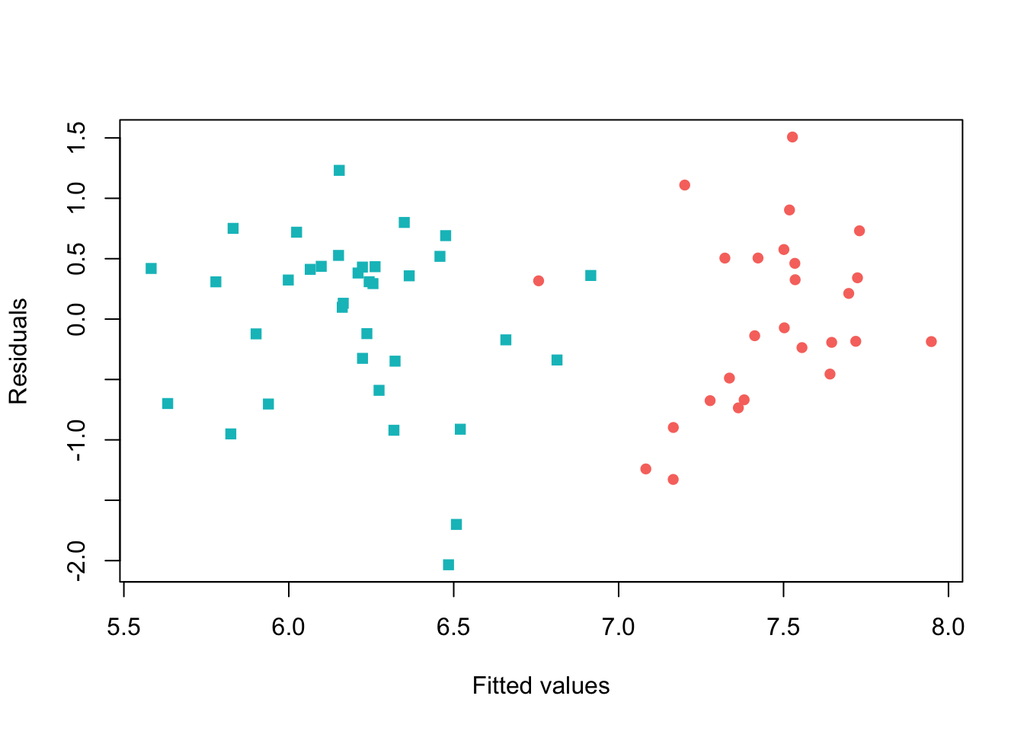

```r
plot(predict(mod_scientist_B), resid(mod_scientist_B),
     xlab = "Fitted values", ylab = "Residuals",
     col = colors[as.numeric(cortisol$group == "NC") + 1],
     pch = 15 + as.numeric(cortisol$group == "C"))
```

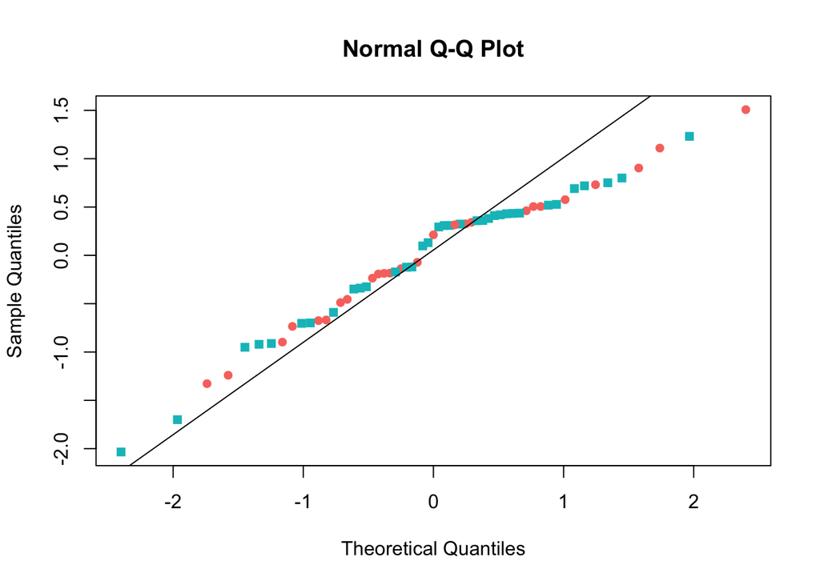

```r
qqnorm(resid(mod_scientist_B), col = colors[as.numeric(cortisol$group == "NC") + 1],
       pch = 15 + as.numeric(cortisol$group == "C"))
qqline(resid(mod_scientist_A))
```

These graphs show that this model proposed by Scientist B appears to be better than the first model. However, the fit is still relatively poor as can be observed in the second graph.

In terms of AIC, the second model is clearly better with smaller AIC. Indeed, we have:

```r
AIC(mod_scientist_A)
```

```
## [1] 160.6592
```

```r
AIC(mod_scientist_B)
```

```
## [1] 137.3906
```

We could consider a third model where we don’t require the slopes to be the same in both groups:

```r
# A new model
mod3 = lm(log_cortisol ~ caloric*group, data = cortisol)
summary(mod3)
```

```
##
## Call:
## lm(formula = log_cortisol ~ caloric * group, data = cortisol)
##
## Residuals:
##     Min      1Q  Median      3Q     Max
## -1.9326 -0.5473  0.1135  0.5044  1.4510
##
## Coefficients:
##                  Estimate Std. Error t value Pr(>|t|)
## (Intercept)      3.396770   1.338092   2.539  0.01389 *
## caloric          0.001738   0.000571   3.045  0.00352 **
## groupNC          0.564147   1.983381   0.284  0.77711
## caloric:groupNC -0.001106   0.000703  -1.573  0.12131
## ---
## Signif. codes:  0 '***' 0.001 '**' 0.01 '*' 0.05 '.' 0.1 ' ' 1
##
## Residual standard error: 0.7077 on 57 degrees of freedom
## Multiple R-squared:  0.5008, Adjusted R-squared:  0.4746
## F-statistic: 19.06 on 3 and 57 DF,  p-value: 1.103e-08
```

Let’s evaluate the adequacy of this model with the data:

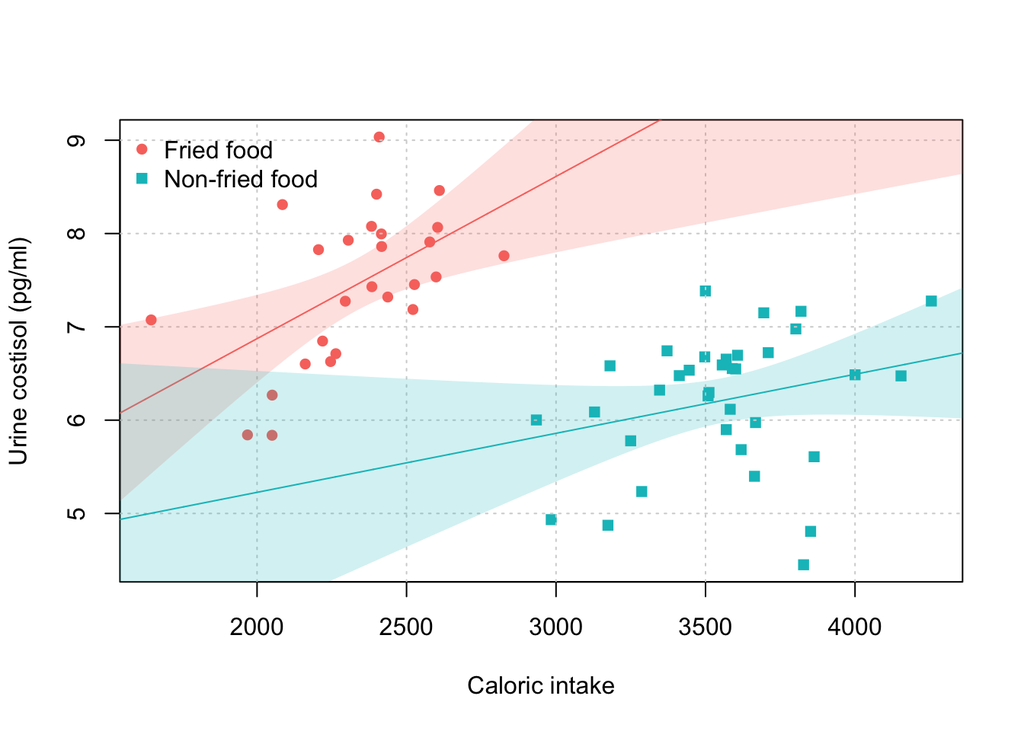

```r
colors = c("#F8766D", "#00BFC4")
plot(cortisol$caloric, cortisol$log_cortisol,
     xlab = "Caloric intake", ylab = "Urine costisol (pg/ml)",
     col = colors[as.numeric(cortisol$group == "NC") + 1],
     pch = 15 + as.numeric(cortisol$group == "C"))
grid()
legend("topleft", c("Fried food", "Non-fried food"), col = colors, pch = c(16, 15), bty = "n")

cal_to_predict = 1500:4500
pred_C = predict(mod3, data.frame(caloric = cal_to_predict, group = rep("C", length(cal_to_predict))), interval = "confidence")
pred_NC = predict(mod3, data.frame(caloric = cal_to_predict, group = rep("NC", length(cal_to_predict))), interval = "confidence")

lines(cal_to_predict, pred_C[,1], col = "#F8766D")
polygon(c(cal_to_predict, rev(cal_to_predict)), c(pred_C[,2], rev(pred_C[,3])), col = "#F8766D33", border = NA)

lines(cal_to_predict, pred_NC[,1], col = "#00BFC4")
polygon(c(cal_to_predict, rev(cal_to_predict)), c(pred_NC[,2], rev(pred_NC[,3])), col = "#00BFC433", border = NA)
```

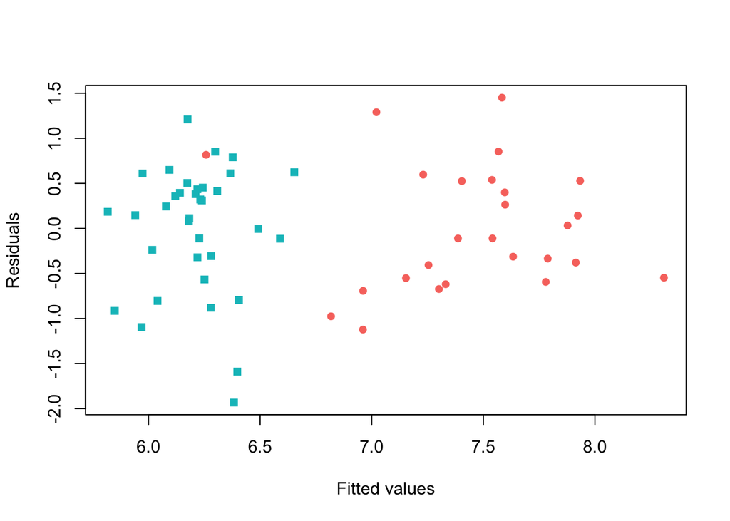

```r
plot(predict(mod3), resid(mod3),
     xlab = "Fitted values", ylab = "Residuals",
     col = colors[as.numeric(cortisol$group == "NC") + 1],
     pch = 15 + as.numeric(cortisol$group == "C"))
```

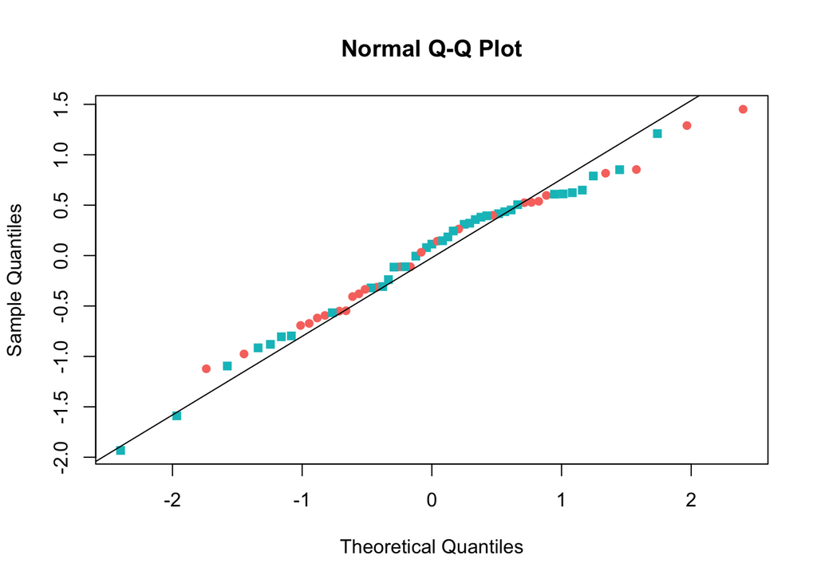

```r
qqnorm(resid(mod3), col = colors[as.numeric(cortisol$group == "NC") + 1],
       pch = 15 + as.numeric(cortisol$group == "C"))
qqline(resid(mod3))
```

This third model appears to be more adequate to describe our data than the first two models. Moreover, its AIC is the lowest, indicating that this model is more adequate. Indeed, we have:

```r
AIC(mod_scientist_A)
```

```
## [1] 160.6592
```

```r
AIC(mod_scientist_B)
```

```
## [1] 137.3906
```

```r
AIC(mod3)
```

```
## [1] 136.7992
```

Interestingly, our conclusions will now depend on the model we decide to select. As the first model appears inadequate, we only consider the last two models. Based on these models, the claim of Scientist A that “*higher caloric intake leads to a lower cortisol level*” appears to be unfounded. Scientist A only managed to validate his/her claim by considering an incorrect model. This phenomenon is called “Simpson’s paradox” where a trend appears without considering different groups but the trend appears in the opposite direction when the groups are considered. This phenomenon is well illustrated in the animation below:

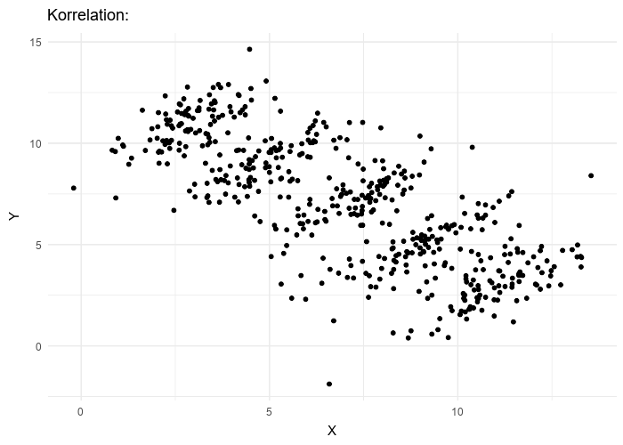

The claim of Scientist B that “*caloric intake has significant impact on the cortisol level*” appears reasonable since at the 95% confidence level we could accept the alternative hypothesis associated to this claim for both models. However, the validity of the claim that “*a higher amount of fried food consumption corresponds to a higher cortisol level*” depends on the model we select. Indeed, for the first model (i.e. the model of Scientist B) we could accept the alternative hypothesis associated to this claim but this is not the case for the second model (i.e. `mod3`). This can probably be explained by the fact that the claim “*a higher amount of fried food consumption corresponds to a higher cortisol level*” is associated to two parameters in the second model (but only to one parameter in the first model), making the analysis more complicated and difficult for interpretation. In conclusion, while the second model appears to be more suitable, it may not provide us with a suitable approach to assess the validity of the claim “*a higher amount of fried food consumption corresponds to a higher cortisol level*”. In such case, the model proposed by Scientist B could arguably be preferred for its better interpretability.